# Homework #8: Clustering

Jie Tang

Due: Tue Apr 26 | 10:30am

**SYS 4582/6018 | Spring 2022 | University of Virginia**

# Required R packages and Directories

```r
data.dir = 'https://mdporter.github.io/SYS6018/data/' # data directory
library(R6018)     # functions for SYS-6018
library(tidyverse) # functions for data manipulation
library(mclust)    # functions for mixture models
library(mixtools)  # poisregmixEM() function
```

# Problem 1: Customer Segmentation with RFM (Recency, Frequency, and Monetary Value)

RFM analysis is an approach that some businesses use to understand their customers’ activities. At any point in time, a company can measure how recently a customer purchased a product (Recency), how many times they purchased a product (Frequency), and how much they have spent (Monetary Value). There are many ad-hoc attempts to segment/cluster customers based on the RFM scores (e.g., here is one based on using the customers’ rank of each dimension independently: https://joaocorreia.io/blog/rfm-analysis-increase-sales-by-segmenting-your-customers.html). In this problem you will use the clustering methods we covered in class to segment the customers.

The data for this problem can be found here: https://mdporter.github.io/SYS6018/data//RFM.csv. Cluster based on the Recency, Frequency, and Monetary value columns.

```r
data = read.csv('https://mdporter.github.io/SYS6018/data//RFM.csv')
```

## a. Implement hierarchical clustering.

- Describe any pre-processing steps you took (e.g., scaling, distance metric)
- State the linkage method you used with justification.
- Show the resulting dendrogram
- State the number of segments/clusters you used with justification.
- Using your segmentation, are customers 1 and 100 in the same cluster?

I chose euclidean method as distance calculation method, Ward’s as linkage calculation method. With a scaling to mean = 0 sd= 1, we can make each variable with a same range. It can help us calculate a precise distance outcome. With Ward’s linkage, we calculate the increase in sum of squares. I think with this dissimilarity calculation, it is effective method for noisy data.

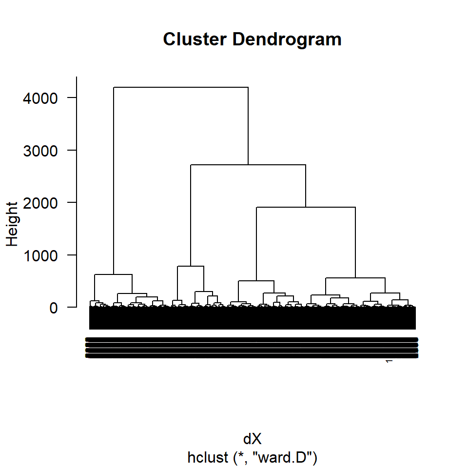

```r
X = dplyr::select(data, Recency, Frequency, Monetary)
X <- scale(X) #mean = 0 sd = 1
dX = dist(X, method='euclidean')
#Ward's Linkage as linkage method
hc = hclust(dX, method="ward.D") # ward's linkage
plot(hc, las=1, cex=.6)
```

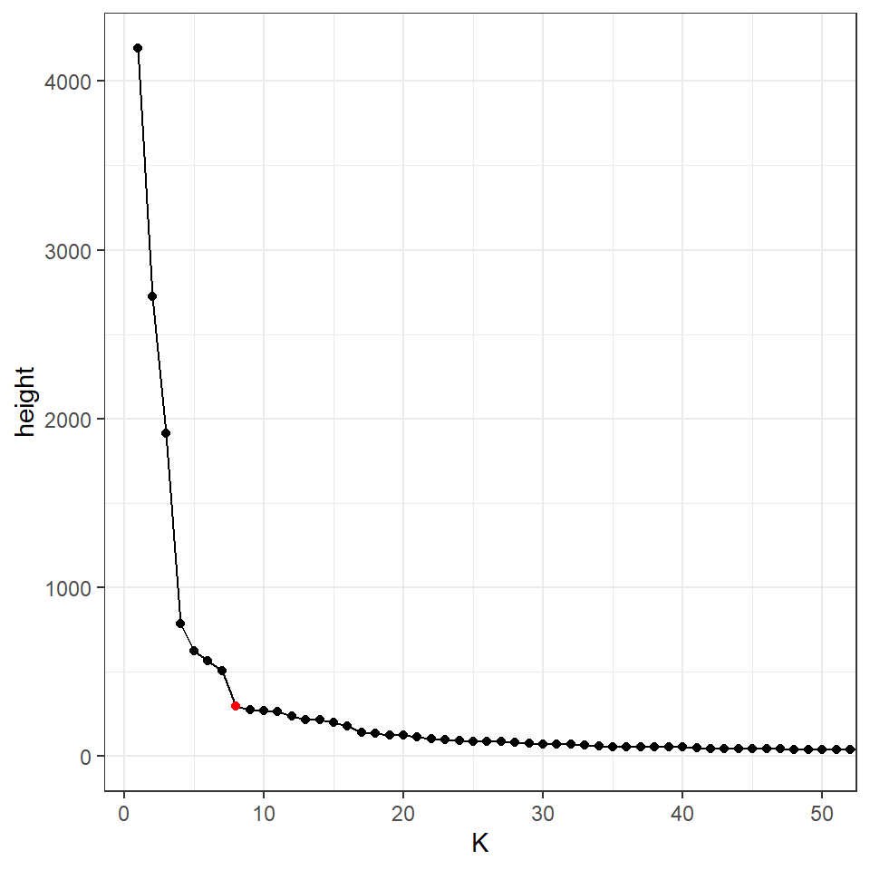

```r
#By using ward's method,the gap of heights corresponds to the change in the Sum #of Squared Errors (SSE) for a merge
tibble(height = hc$height, K = row_number(-height)) %>%
ggplot(aes(K, height)) +
geom_line() +
geom_point(aes(color = ifelse(K == 8, "red", "black"))) +
scale_color_identity() +
coord_cartesian(xlim=c(1, 50))
```

```r
#membership
member1 = cutree(hc, k=8)
#They are not in same cluster, when k = 8
member1[1]== member1[100]
```

```
#> [1] FALSE
```

We can look for the elbow point. From above figure, I picked cluster number equal to eight So, we have eight cluster.

## b. Implement k-means.

- Describe any pre-processing steps you took (e.g., scaling)
- State the number of segments/clusters you used with justification.
- Using your segmentation, are customers 1 and 100 in the same cluster?

```r
#With same scaling data from above, we scale data to mean=0 sd=1.
#By scaling the data (so each feature has the same variance), the resulting clustering can better adapt to the natural structure
#From above result, we estimate the clusters is eight.I set the kmax = 15. We can see whether elbow point is located in near point eight.
Kmax = 15
SSE = numeric(Kmax)
for(k in 1:Kmax){
  km = kmeans(X, centers=k, nstart=25)    # use 25 starts
  SSE[k] = km$tot.withinss                # get SSE
}
```

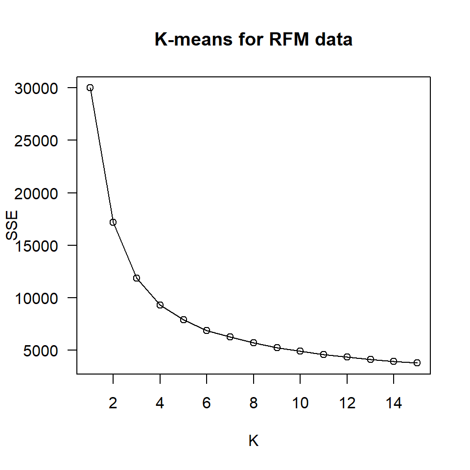

```r
#-- Plot results
plot(1:Kmax, SSE, type='o', las=1, xlab="K")
title("K-means for RFM data")
```

```r
#We pick the elbow point, which seems like point six in graph.
km = kmeans(X, centers=6, nstart=25) # use K=6
#membership
member2 = km$cluster
#They are not same cluster, when k = 6.
member2[1] == member2[100]
```

```
#> [1] FALSE
```